# Overview

My project is to explore the performance of predicting ventilator pressure using machine learning. The data I am using are shared through a Kaggle competition that hosted by Google brain and Prinston University (https://www.kaggle.com/c/ventilator-pressure-prediction/overview).

The three faculty/staff advisors for my projects are: Tsui Rich, Ruiz Victor, Russel Richie. During our discussion, they gave me suggestions on model selection, recurrent model techniques, and time-seires feature engineering.

The final project GitHub repository:https://github.com/helenshi-chop/BMIN503_Final_Project

# Introduction

Clinicians use mechanical ventilator to help patients who have trouble breathing.But it is a labor intensive treatment. Especially in the early stage of COVID-pandemic, this caused a lot loss due to a shortage of clinicians. Develop automatic ventilator could relieve the burden but that requires precise pressure control and adaption to different lung attributes. I will explore using Deep Learning and time-seines data analysis to predict inspiration pressure of each breath. This is cross-disciplinarian problem as it requires knowledge in mechanics, machine learning, time-series modeling, and deep learning. In the meeting the faculty, we brain-stormed that recurrent neural network may potentially catch the time-series subtle changes during breath.

# Method

## Data Description

```python
!jupyter nbextension enable --py widgetsnbextension
```

```
Enabling notebook extension jupyter-js-widgets/extension...
      - Validating: OK
```

```python
# load data and analyze data distribution of each column
import pandas as pd
from pandas_profiling import ProfileReport
df = pd.read_csv("ventilator_pressure_predict_train.csv")
```

## Data characteristics and predictors introduction

In total, there are 75,450 breath records, each lasts for around 3 seconds (can see from the time_step, which is the relative time to a start of a breath); Predictors include:

1. R: lung attribute
2. C: lung attribute
3. u_in: the pressure of inspiratory solenoid valve; Ranges from 0 to 100
4. u_out: the open status of the exploratory solenoid valve; Either 0 or 1
5. pressure: pressure measurements in previous time steps

The outcome to predict is pressure: the airway pressure measured in the respiratory circuit, measured in cmH2O.

The following plot shows the pressure, u_in, and u_out for one breath process

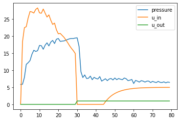

```python
import matplotlib.pyplot as plt
%matplotlib inline
import warnings

warnings.simplefilter('ignore')
df[df['breath_id']==1][['pressure','u_in','u_out']].plot()
plt.show()
```

## Machine Learning

The whole dataset was randomly split as training+development (70%) and testing (30%). The training and development datasets were used to develop traditional machine learning (regression-based) and deep learning models and tune hyperparameters for the developed models. The testing dataset was hold out for evaluating and reporting the model performance.

### Evaluation

The study reported the following 5 evaluation metrics: MSE: mean squared error MAE: mean absolute error RMSE: root mean squared error MAPE: mean absolute percentage error R2: coefficient of determination

```python
# Evaluation functions
from sklearn import metrics
import numpy as np
def timeseries_evaluation_metrics_func(y_true, y_pred):

    def mean_absolute_percentage_error(y_true, y_pred):
        y_true, y_pred = np.array(y_true), np.array(y_pred)
        return np.mean(np.abs((y_true - y_pred) / y_true)) * 100
    print('Evaluation metric results:-')
    print(f'MSE is : {metrics.mean_squared_error(y_true, y_pred)}')
    print(f'MAE is : {metrics.mean_absolute_error(y_true, y_pred)}')
    print(f'RMSE is : {np.sqrt(metrics.mean_squared_error(y_true, y_pred))}')
    print(f'MAPE is : {mean_absolute_percentage_error(y_true, y_pred)}')
    print(f'R2 is : {metrics.r2_score(y_true, y_pred)}',end='\n\n')

    result = {}
    result['MSE'] = metrics.mean_squared_error(y_true, y_pred)
    result['MAE'] = metrics.mean_absolute_error(y_true, y_pred)
    result['RMSE'] = np.sqrt(metrics.mean_squared_error(y_true, y_pred))
    result['MAPE'] = mean_absolute_percentage_error(y_true, y_pred)
    result['R2'] = metrics.r2_score(y_true, y_pred)

    return(result)
```

### Baseline-approach: Multivariate Time Series – VAR

A Multivariate time series has more than one time-dependent variable. Each variable depends not only on its past values but also has some dependency on other variables. Vector Auto Regression (VAR) is one of the most commonly used method for multivariate time series prediction. So here VAR was selected to model the baseline performance of predicting pressure given predictors in past time steps.

For VAR models, Akaike and Bayesian Information Criterion are two ways of scoring a model based on its log-likelihood and complexity, the less the better, so here both AIC and BIC were used to select lag order of the VAR mdoel. A lag is the value of a variable in a previous time period, so a pth-order VAR refers to a VAR model which includes lags for the last p time periods. The study tested lag order from 1 to 9 and selected the best lag order to build the VAR model from training dataset.

Randomly split training (70%) and testing (30%) datasets

```python
import math
import random
random.seed(10)
train_breath_ids = random.sample(list(df.breath_id.unique()), math.floor(df['breath_id'].nunique()*0.7))
test_breath_ids = list(set(list(df.breath_id.unique()))-set(train_breath_ids))
print("Training sample: {}, Testing sample: {}".format(len(train_breath_ids), len(test_breath_ids)))
train_df = df[df['breath_id'].isin(train_breath_ids)]
test_df = df[df['breath_id'].isin(test_breath_ids)]
```

```
Training sample: 52815, Testing sample: 22635
```

```python
from statsmodels.tsa.vector_ar.var_model import VAR

X=['R','C','pressure','u_in','u_out']
for i in [1,2,3,4,5,6,7,8,9]:
    model = VAR(train_df[X].values)
    results = model.fit(i)
    print(f'Order : {i}, AIC:  {results.aic}, BIC: { results.bic}')
```

```
Order : 1, AIC:  5.576774971826571, BIC: 5.57686909693347
Order : 2, AIC:  5.481758331928312, BIC: 5.481930894662055
Order : 3, AIC:  4.93039766060675, BIC: 4.930648661001665
Order : 4, AIC:  4.894819862986137, BIC: 4.895149301076551
Order : 5, AIC:  4.879491018501405, BIC: 4.879898894321645
Order : 6, AIC:  4.870099495184626, BIC: 4.870585808769022
Order : 7, AIC:  4.845158573212884, BIC: 4.845723324595761
Order : 8, AIC:  4.837369073660657, BIC: 4.838012262876346
Order : 9, AIC:  4.831516640606186, BIC: 4.8322382676890125
```

Autoregressive AR(9) appears to be providing the least Akaike Information Criterion (AIC) and Bayesian Information Criterion (BIC), so let’s fit and forecast.

```python
from statsmodels.tsa.vector_ar.var_model import VAR
X=['R','C','pressure','u_in','u_out']
model = VAR(train_df[X].values)
model_fit = model.fit(9)
display(model_fit.summary())
```

```
  Summary of Regression Results
==================================
Model:                         VAR
Method:                        OLS
Date:           Fri, 10, Dec, 2021
Time:                     11:57:50
--------------------------------------------------------------------
No. of Equations:         5.00000    BIC:                    4.83224
Nobs:                 4.22519e+06    HQIC:                   4.83170
Log likelihood:      -4.01832e+07    FPE:                    125.401
AIC:                      4.83152    Det(Omega_mle):         125.394
--------------------------------------------------------------------
Results for equation y1
========================================================================
           coefficient       std. error           t-stat            prob
------------------------------------------------------------------------
const         0.348340         0.007151           48.709           0.000
L1.y1         0.993182         0.000490         2027.708           0.000
L1.y2         0.000275         0.000558            0.492           0.623
L1.y3         0.005613         0.001101            5.100           0.000
L1.y4        -0.000313         0.000244           -1.286           0.198
L1.y5        -0.030249         0.009897           -3.056           0.002
L2.y1        -0.000027         0.000690           -0.039           0.969
L2.y2         0.000047         0.000787            0.060           0.952
L2.y3        -0.002804         0.001622           -1.729           0.084
L2.y4        -0.000393         0.000312           -1.260           0.208
L2.y5        -0.000821         0.013585           -0.060           0.952
L3.y1        -0.000194         0.000691           -0.281           0.779
L3.y2         0.000034         0.000787            0.043           0.966
L3.y3         0.001765         0.001645            1.073           0.283
L3.y4        -0.000738         0.000323           -2.286           0.022
L3.y5         0.021711         0.014159            1.533           0.125
L4.y1        -0.000304         0.000691           -0.440           0.660
L4.y2         0.000018         0.000787            0.023           0.982
L4.y3        -0.000230         0.001646           -0.140           0.889
L4.y4        -0.000147         0.000342           -0.430           0.667
L4.y5        -0.004178         0.014555           -0.287           0.774
L5.y1         0.000012         0.000693            0.017           0.987
L5.y2         0.000062         0.000787            0.079           0.937
L5.y3        -0.001921         0.001654           -1.161           0.246
```

[output cut: 224 more lines]

```
L8.y5        -0.004922         0.000729           -6.748           0.000
L9.y1         0.000080         0.000025            3.240           0.001
L9.y2         0.000029         0.000028            1.040           0.298
L9.y3         0.001592         0.000042           37.553           0.000
L9.y4        -0.000406         0.000014          -28.731           0.000
L9.y5        -0.008367         0.000560          -14.946           0.000
========================================================================

Correlation matrix of residuals
            y1        y2        y3        y4        y5
y1    1.000000 -0.096280 -0.005073 -0.061800 -0.001352
y2   -0.096280  1.000000  0.019266  0.015535  0.001855
y3   -0.005073  0.019266  1.000000 -0.281893  0.029091
y4   -0.061800  0.015535 -0.281893  1.000000 -0.193393
y5   -0.001352  0.001855  0.029091 -0.193393  1.000000
```

*Evaluate VAR model on test dataset*

```python
forecast_input_test = test_df[X].values
test_pred = model_fit.forecast(forecast_input_test, len(forecast_input_test))
test_result = pd.concat([pd.DataFrame(forecast_input_test, columns=X), pd.DataFrame(test_pred, columns=list(map(lambda n: "pred_"+n, X)))], axis=1)
test_result.to_csv("VARtest_result.csv", index=False)
timeseries_evaluation_metrics_func(test_result['pressure'].values, test_result['pred_pressure'].values)
```

```
Evaluation metric results:-
MSE is : 65.29178898107024
MAE is : 6.186044354339229
RMSE is : 8.080333469670062
MAPE is : 66.19809941638246
R2 is : -1.6502196972467686e-05
```

### Deep Learning Models

Recent developments in deep learning methods offers a lot of promise for time series modeling. It can learn the temporal dependence and handle temporal structures like trends and seasonality without manual feature curation. Most used deep learning networks in time-series analysis include Recurrent Neural Network (RNN), Long short-term memory (LSTM), and Gated Recurrent Units (GRU), and Convolutional Neural Network (CNN). This study explored Bi-LSTM, GRU, and CNN.

#### Prepare trainnig, testing, valdiation datasets

```python
import pandas as pd
import numpy as np
import tensorflow as tf
from tensorflow import keras
from sklearn import preprocessing
import matplotlib.pyplot as plt
import math
from tensorflow.keras.models import Sequential
from tensorflow.keras.layers import Dense
from tensorflow.keras.layers import Flatten,TimeDistributed,RepeatVector
from tensorflow.keras.layers import Conv1D
from tensorflow.keras.layers import MaxPool1D
from tensorflow.keras.layers import Dropout

tf.random.set_seed(123)
np.random.seed(123)

X=['R','C','pressure','u_in','u_out']
df = train_df[X]

def custom_ts_multi_data_prep(dataset, target, start, end, window, horizon):
    X = []
    y = []
    start = start + window
    if end is None:
        end = len(dataset) - horizon

    for i in range(start, end):
        indices = range(i-window, i)
        X.append(dataset[indices])

        indicey = range(i+1, i+1+horizon)
        y.append(target[indicey])
    return np.array(X), np.array(y)

x_scaler = preprocessing.MinMaxScaler()
y_scaler = preprocessing.MinMaxScaler()
dataX = x_scaler.fit_transform(df)
dataY = y_scaler.fit_transform(df[['pressure']])
```

#### Run experiment: Horizon-style prediction

history window: 40 horizon: 20

```python
hist_window = 40
horizon = 20
TRAIN_SPLIT = math.floor(df.shape[0]*0.9)
x_train_multi, y_train_multi = custom_ts_multi_data_prep(
    dataX, dataY, 0, TRAIN_SPLIT, hist_window, horizon)
x_val_multi, y_val_multi= custom_ts_multi_data_prep(
    dataX, dataY, TRAIN_SPLIT, None, hist_window, horizon)
print ('Single window of past history')
print(x_train_multi[0])
print ('\n Target horizon')
print (y_train_multi[0])
```

```
Single window of past history
[[3.33333333e-01 1.00000000e+00 1.15911486e-01 8.33340056e-04
  0.00000000e+00]
 [3.33333333e-01 1.00000000e+00 1.16965227e-01 1.83830415e-01
  0.00000000e+00]
 [3.33333333e-01 1.00000000e+00 1.46469968e-01 2.25092778e-01
  0.00000000e+00]
 [3.33333333e-01 1.00000000e+00 2.04425711e-01 2.28088223e-01
  0.00000000e+00]
 [3.33333333e-01 1.00000000e+00 2.11801897e-01 2.53558503e-01
  0.00000000e+00]
 [3.33333333e-01 1.00000000e+00 2.21285564e-01 2.72598659e-01
  0.00000000e+00]
 [3.33333333e-01 1.00000000e+00 2.48682824e-01 2.71274856e-01
  0.00000000e+00]
 [3.33333333e-01 1.00000000e+00 2.66596417e-01 2.68077318e-01
  0.00000000e+00]
 [3.33333333e-01 1.00000000e+00 2.61327713e-01 2.78647154e-01
  0.00000000e+00]
 [3.33333333e-01 1.00000000e+00 2.64488936e-01 2.83130358e-01
  0.00000000e+00]
 [3.33333333e-01 1.00000000e+00 2.87671233e-01 2.68667582e-01
  0.00000000e+00]
 [3.33333333e-01 1.00000000e+00 2.86617492e-01 2.67628026e-01
  0.00000000e+00]
 [3.33333333e-01 1.00000000e+00 2.70811380e-01 2.79932736e-01
  0.00000000e+00]
 [3.33333333e-01 1.00000000e+00 2.88724974e-01 2.67898980e-01
  0.00000000e+00]
 [3.33333333e-01 1.00000000e+00 2.99262381e-01 2.56340700e-01
  0.00000000e+00]
 [3.33333333e-01 1.00000000e+00 2.85563751e-01 2.62801953e-01
  0.00000000e+00]
 [3.33333333e-01 1.00000000e+00 3.02423604e-01 2.47267144e-01
  0.00000000e+00]
 [3.33333333e-01 1.00000000e+00 3.09799789e-01 2.34678886e-01
  0.00000000e+00]
 [3.33333333e-01 1.00000000e+00 2.96101159e-01 2.38584342e-01
  0.00000000e+00]
 [3.33333333e-01 1.00000000e+00 3.15068493e-01 2.18834035e-01
```

[output cut: 48 more lines]

```
 [0.13277134]
 [0.14014752]
 [0.14225501]
 [0.13593256]
 [0.14436249]
 [0.1369863 ]
 [0.14225501]
 [0.13909378]
 [0.1369863 ]
 [0.14436249]
 [0.14120126]
 [0.13277134]
 [0.13487882]
 [0.13804004]
 [0.12012645]]
```

```python
#### Prepare training and validation and test datasets in time-series format
```

```python
BATCH_SIZE = 256
BUFFER_SIZE = 150

train_data_multi = tf.data.Dataset.from_tensor_slices((x_train_multi, y_train_multi))
train_data_multi = train_data_multi.cache().shuffle(BUFFER_SIZE).batch(BATCH_SIZE).repeat()

val_data_multi = tf.data.Dataset.from_tensor_slices((x_val_multi, y_val_multi))
val_data_multi = val_data_multi.batch(BATCH_SIZE).repeat()
```

#### Define Deep Learning Models

```python
# Bi-LSTM
Bi_lstm_model = tf.keras.models.Sequential([
  tf.keras.layers.Bidirectional(tf.keras.layers.LSTM(150, return_sequences=True),
                               input_shape=x_train_multi.shape[-2:]),
    tf.keras.layers.Bidirectional(tf.keras.layers.LSTM(50)),
    tf.keras.layers.Dense(20, activation='tanh'),
    tf.keras.layers.Dropout(0.2),
    tf.keras.layers.Dense(units=horizon),
])
Bi_lstm_model.compile(optimizer='adam', loss='mse')


# GRU
GRU_model = tf.keras.models.Sequential([
    tf.keras.layers.GRU(100, input_shape=x_train_multi.shape[-2:],return_sequences=True),
    tf.keras.layers.Dropout(0.2),
    tf.keras.layers.GRU(units=50,return_sequences=False),
    tf.keras.layers.Dropout(0.2),
    tf.keras.layers.Dense(units=horizon),
])
GRU_model.compile(optimizer='adam', loss='mse')

# CNN
CNN_model = Sequential()
CNN_model.add(Conv1D(filters=64, kernel_size=3, activation='relu', input_shape=(x_train_multi.shape[1], x_train_multi.shape[2])))
CNN_model.add(MaxPool1D(pool_size=2))
CNN_model.add(Dropout(0.2))
CNN_model.add(Flatten())
CNN_model.add(Dense(30, activation='relu'))
CNN_model.add(Dropout(0.2))
CNN_model.add(Dense(horizon))
CNN_model.compile(optimizer='adam', loss='mse')
```

#### train DNN models

```python
model_list = {"bilstm": Bi_lstm_model, "GRU": GRU_model, "CNN": CNN_model}
for x in model_list:
    print(x, model_list[x])
```

```
bilstm <tensorflow.python.keras.engine.sequential.Sequential object at 0x7f1fce749d50>
GRU <tensorflow.python.keras.engine.sequential.Sequential object at 0x7f1f802b1790>
CNN <tensorflow.python.keras.engine.sequential.Sequential object at 0x7f1f5edc0dd0>
```

```python
model_list = {"bilstm": Bi_lstm_model, "GRU": GRU_model, "CNN": CNN_model}
history_list = []
for model_key in model_list:
    model_path = model_key
    model = model_list[model_key]
    cp_earlystop = tf.keras.callbacks.EarlyStopping(monitor='val_loss', min_delta=0, patience=5, verbose=1, mode='min')
    cp_callback = tf.keras.callbacks.ModelCheckpoint(filepath=model_path,
                                                     monitor='val_loss',
                                                     save_best_only=True,
                                                     mode='min',
                                                     save_weights_only=True,
                                                     verbose=1)


    EVALUATION_INTERVAL = 100
    EPOCHS = 100
    history = model.fit(train_data_multi, epochs=EPOCHS, steps_per_epoch=EVALUATION_INTERVAL, validation_data=val_data_multi, validation_steps=50, verbose=1,
                                       callbacks=[cp_earlystop, cp_callback])
    history_list.append(history)
```

```
Train for 100 steps, validate for 50 steps
Epoch 00001: val_loss improved from inf to 0.00851, saving model to bilstm
Epoch 00002: val_loss improved from 0.00851 to 0.00696, saving model to bilstm
Epoch 00003: val_loss improved from 0.00696 to 0.00605, saving model to bilstm
Epoch 00004: val_loss did not improve from 0.00605
Epoch 00005: val_loss improved from 0.00605 to 0.00577, saving model to bilstm
Epoch 00006: val_loss did not improve from 0.00577
Epoch 00007: val_loss improved from 0.00577 to 0.00531, saving model to bilstm
Epoch 00008: val_loss improved from 0.00531 to 0.00530, saving model to bilstm
Epoch 00009: val_loss did not improve from 0.00530
Epoch 00010: val_loss improved from 0.00530 to 0.00516, saving model to bilstm
Epoch 00011: val_loss improved from 0.00516 to 0.00491, saving model to bilstm
Epoch 00012: val_loss did not improve from 0.00491
Epoch 00013: val_loss improved from 0.00491 to 0.00488, saving model to bilstm
Epoch 00014: val_loss improved from 0.00488 to 0.00470, saving model to bilstm
Epoch 00015: val_loss did not improve from 0.00470
Epoch 00016: val_loss improved from 0.00470 to 0.00465, saving model to bilstm
Epoch 00017: val_loss did not improve from 0.00465
Epoch 00018: val_loss did not improve from 0.00465
Epoch 00019: val_loss did not improve from 0.00465
Epoch 00020: val_loss did not improve from 0.00465
Epoch 00021: val_loss improved from 0.00465 to 0.00449, saving model to bilstm
Epoch 00022: val_loss did not improve from 0.00449
Epoch 00023: val_loss did not improve from 0.00449
Epoch 00024: val_loss improved from 0.00449 to 0.00448, saving model to bilstm
Epoch 00025: val_loss did not improve from 0.00448
Epoch 00026: val_loss did not improve from 0.00448
Epoch 00027: val_loss did not improve from 0.00448
Epoch 00028: val_loss did not improve from 0.00448
Epoch 00029: val_loss did not improve from 0.00448
Epoch 00029: early stopping
Train for 100 steps, validate for 50 steps
Epoch 00001: val_loss improved from inf to 0.00988, saving model to GRU
Epoch 00002: val_loss improved from 0.00988 to 0.00887, saving model to GRU
Epoch 00003: val_loss improved from 0.00887 to 0.00811, saving model to GRU
Epoch 00004: val_loss improved from 0.00811 to 0.00772, saving model to GRU
Epoch 00005: val_loss improved from 0.00772 to 0.00652, saving model to GRU
Epoch 00006: val_loss improved from 0.00652 to 0.00637, saving model to GRU
Epoch 00007: val_loss did not improve from 0.00637
Epoch 00008: val_loss improved from 0.00637 to 0.00588, saving model to GRU
```

[output cut: 48 more lines]

```
Epoch 00013: val_loss improved from 0.00489 to 0.00470, saving model to CNN
Epoch 00014: val_loss did not improve from 0.00470
Epoch 00015: val_loss improved from 0.00470 to 0.00464, saving model to CNN
Epoch 00016: val_loss did not improve from 0.00464
Epoch 00017: val_loss did not improve from 0.00464
Epoch 00018: val_loss did not improve from 0.00464
Epoch 00019: val_loss did not improve from 0.00464
Epoch 00020: val_loss improved from 0.00464 to 0.00458, saving model to CNN
Epoch 00021: val_loss improved from 0.00458 to 0.00449, saving model to CNN
Epoch 00022: val_loss did not improve from 0.00449
Epoch 00023: val_loss did not improve from 0.00449
Epoch 00024: val_loss did not improve from 0.00449
Epoch 00025: val_loss did not improve from 0.00449
Epoch 00026: val_loss did not improve from 0.00449
Epoch 00026: early stopping
```

```python
model_list = {"bilstm": Bi_lstm_model, "GRU": GRU_model, "CNN": CNN_model}
for model_key in model_list:
    model = model_list[model_key]
    model_path = model_key
    model.load_weights(model_path)
    model.summary()
```

```
Model: "sequential"
_________________________________________________________________
Layer (type)                 Output Shape              Param #
=================================================================
bidirectional (Bidirectional (None, 40, 300)           187200
_________________________________________________________________
bidirectional_1 (Bidirection (None, 100)               140400
_________________________________________________________________
dense (Dense)                (None, 20)                2020
_________________________________________________________________
dropout (Dropout)            (None, 20)                0
_________________________________________________________________
dense_1 (Dense)              (None, 20)                420
=================================================================
Total params: 330,040
Trainable params: 330,040
Non-trainable params: 0
_________________________________________________________________
Model: "sequential_1"
_________________________________________________________________
Layer (type)                 Output Shape              Param #
=================================================================
gru (GRU)                    (None, 40, 100)           32100
_________________________________________________________________
dropout_1 (Dropout)          (None, 40, 100)           0
_________________________________________________________________
gru_1 (GRU)                  (None, 50)                22800
_________________________________________________________________
dropout_2 (Dropout)          (None, 50)                0
_________________________________________________________________
dense_2 (Dense)              (None, 20)                1020
=================================================================
Total params: 55,920
Trainable params: 55,920
Non-trainable params: 0
_________________________________________________________________
Model: "sequential_2"
_________________________________________________________________
Layer (type)                 Output Shape              Param #
=================================================================
conv1d (Conv1D)              (None, 38, 64)            1024
_________________________________________________________________
max_pooling1d (MaxPooling1D) (None, 19, 64)            0
_________________________________________________________________
dropout_3 (Dropout)          (None, 19, 64)            0
_________________________________________________________________
flatten (Flatten)            (None, 1216)              0
_________________________________________________________________
dense_3 (Dense)              (None, 30)                36510
_________________________________________________________________
dropout_4 (Dropout)          (None, 30)                0
_________________________________________________________________
dense_4 (Dense)              (None, 20)                620
=================================================================
Total params: 38,154
Trainable params: 38,154
Non-trainable params: 0
_________________________________________________________________
```

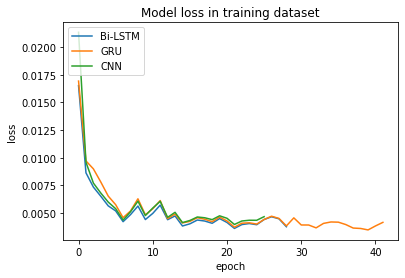

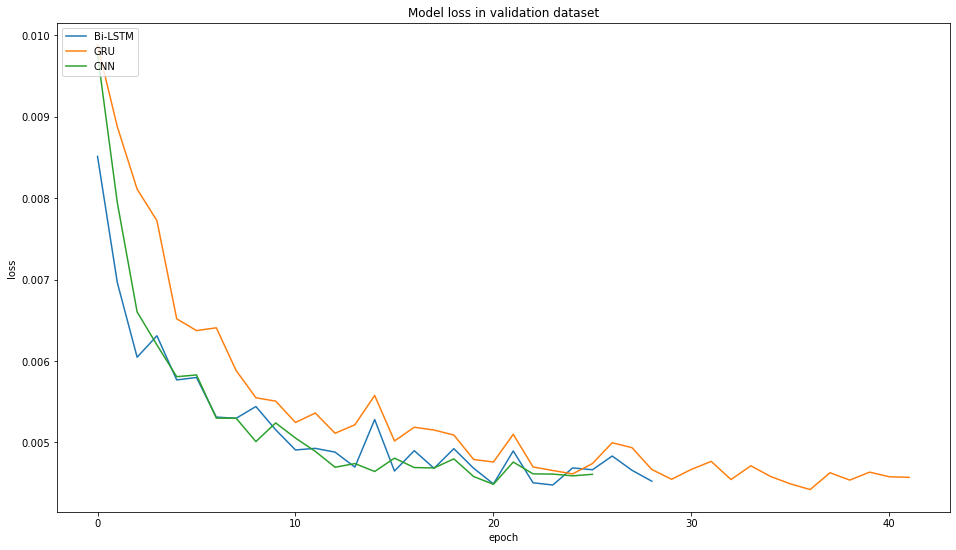

```python
for history in history_list:
    plt.plot(history.history['loss'])
plt.title('Model loss in training dataset')
plt.ylabel('loss')
plt.xlabel('epoch')
plt.legend(['train loss', 'validation loss'], loc='upper left')
plt.legend(['Bi-LSTM', 'GRU','CNN'], loc='upper left')
plt.rcParams["figure.figsize"] = [16,9]
plt.show()

for history in history_list:
    plt.plot(history.history['val_loss'])
plt.title('Model loss in validation dataset')
plt.ylabel('loss')
plt.xlabel('epoch')
plt.legend(['train loss', 'validation loss'], loc='upper left')
plt.legend(['Bi-LSTM', 'GRU','CNN'], loc='upper left')
plt.rcParams["figure.figsize"] = [16,9]
plt.show()
```

```python
#### Evaluate model performance on hold-out testing dataset
```

```python
from tqdm import tqdm
def custom_ts_multi_data_prep(dataset, target, start, end, window, horizon):
    X = []
    y = []
    start = start + window
    if end is None:
        end = len(dataset) - horizon

    for i in range(start, end, horizon):
        indices = range(i-window, i)
        X.append(dataset[indices])

        indicey = range(i+1, i+1+horizon)
        y.append(target[indicey])
    return np.array(X), np.array(y)

for model_key in model_list:
    if model_key!='CNN':
        print("pass "+ model_key)
        continue
    model = model_list[model_key]

    padding_matrix = pd.DataFrame(np.zeros((40, 5)), columns=X)
    test_result = []

    for i in tqdm(range(len(test_breath_ids))):
        test_df_with_padding = pd.concat([padding_matrix,test_df[test_df['breath_id']==test_breath_ids[i]][X]],ignore_index=True)

        x_scaler = preprocessing.MinMaxScaler()
        y_scaler = preprocessing.MinMaxScaler()
        dataX = x_scaler.fit_transform(test_df_with_padding)
        dataY = y_scaler.fit_transform(test_df_with_padding[['pressure']])

        hist_window = 40
        horizon = 20

        x_val_multi, y_val_multi= custom_ts_multi_data_prep(dataX, dataY, 0, None, hist_window, horizon)
        for i in range(len(x_val_multi)):
            val_rescaled = x_val_multi[i].reshape(1, 40, 5)
            Predicted_results = model.predict(val_rescaled)
            Predicted_results_Inv_trans = y_scaler.inverse_transform(Predicted_results)
            test_result.append(np.array(list(zip(Predicted_results_Inv_trans[0], [row[0] for row in y_scaler.inverse_transform(y_val_multi[i])]))))
    test_result_df = pd.DataFrame(np.concatenate(test_result), columns=['pred_pressure','pressure'])
    test_result_df.to_csv(model_key+"test_result.csv", index=False)
    print("MODEL performance ** " + model_key)
    timeseries_evaluation_metrics_func(test_result_df['pressure'].values, test_result_df['pred_pressure'].values)
```

```
pass bilstm
pass GRU
```

```
MODEL performance ** CNN
Evaluation metric results:-
MSE is : 277.19227707219994
MAE is : 13.965647544537065
RMSE is : 16.6490923798326
MAPE is : 113.91073892007215
R2 is : -2.6706516009739847
```

#### Run experiment: Single-style prediction

history window: 20 horizon: 1

```python
hist_window = 20
horizon = 1
TRAIN_SPLIT = math.floor(df.shape[0]*0.9)
x_train_multi, y_train_multi = custom_ts_multi_data_prep(
    dataX, dataY, 0, TRAIN_SPLIT, hist_window, horizon)
x_val_multi, y_val_multi= custom_ts_multi_data_prep(
    dataX, dataY, TRAIN_SPLIT, None, hist_window, horizon)
print ('Single window of past history')
print(x_train_multi[0])
print ('\n Target horizon')
print (y_train_multi[0])
```

[output not shown]

```python
model_list = {"bilstm-single": Bi_lstm_model, "GRU-single": GRU_model, "CNN-single": CNN_model}
history_list = []
for model_key in model_list:
    model_path = model_key
    model = model_list[model_key]
    cp_earlystop = tf.keras.callbacks.EarlyStopping(monitor='val_loss', min_delta=0, patience=5, verbose=1, mode='min')
    cp_callback = tf.keras.callbacks.ModelCheckpoint(filepath=model_path,
                                                     monitor='val_loss',
                                                     save_best_only=True,
                                                     mode='min',
                                                     save_weights_only=True,
                                                     verbose=1)


    EVALUATION_INTERVAL = 100
    EPOCHS = 100
    history = model.fit(train_data_multi, epochs=EPOCHS, steps_per_epoch=EVALUATION_INTERVAL, validation_data=val_data_multi, validation_steps=50, verbose=1,
                                       callbacks=[cp_earlystop, cp_callback])
    history_list.append(history)
```

#### Test the single-style model in randomly sampled test breaths

```python
for model_key in model_list:
    model = model_list[model_key]

    padding_matrix = pd.DataFrame(np.zeros((40, 5)), columns=X)
    test_result = []

    for i in tqdm(range(len(test_breath_ids))):
        test_df_with_padding = pd.concat([padding_matrix,test_df[test_df['breath_id']==test_breath_ids[i]][X]],ignore_index=True)

        x_scaler = preprocessing.MinMaxScaler()
        y_scaler = preprocessing.MinMaxScaler()
        dataX = x_scaler.fit_transform(test_df_with_padding)
        dataY = y_scaler.fit_transform(test_df_with_padding[['pressure']])

        hist_window = 40
        horizon = 20

        x_val_multi, y_val_multi= custom_ts_multi_data_prep(dataX, dataY, 0, None, hist_window, horizon)
        for i in range(len(x_val_multi)):
            val_rescaled = x_val_multi[i].reshape(1, 40, 5)
            Predicted_results = model.predict(val_rescaled)
            Predicted_results_Inv_trans = y_scaler.inverse_transform(Predicted_results)
            test_result.append(np.array(list(zip(Predicted_results_Inv_trans[0], [row[0] for row in y_scaler.inverse_transform(y_val_multi[i])]))))
    test_result_df = pd.DataFrame(np.concatenate(test_result), columns=['pred_pressure','pressure'])
    test_result_df.to_csv(model_key+"test_result.csv", index=False)
    print("MODEL performance ** " + model_key)
    timeseries_evaluation_metrics_func(test_result_df['pressure'].values, test_result_df['pred_pressure'].values)
```

[output not shown]

## Result

We have trained the following models:

- Model #1: VAR model
- Model #2: Horizontal-style Bi-LSTM model
- Model #3: Horizontal-style GRU model
- Model #4: Horizontal-style CNN model
- Model #5: Single-style Bi-LSTM model
- Model #6: Single-style GRU model
- Model #7: Single-style CNN model

Here we compare the evaluation matrix using the following metrics:

- MSE: mean squared error
- MAE: mean absolute error
- RMSE: root mean squared error
- MAPE: mean absolute percentage error
- R2: coefficient of determination

```python
import glob
import pandas as pd

# loop csv files in the path
files = glob.glob("*.csv")

content = []
for filename in files:
    if filename.split('.')[0] == 'ventilator_pressure_predict_train':
        continue
    df = pd.read_csv(filename)
    print("model" +  filename.split('.')[0])
    result =  timeseries_evaluation_metrics_func(df['pressure'].values, df['pred_pressure'].values)
    result_df = pd.DataFrame(result.items())
    result_df['model'] = filename.split('.')[0]
    content.append(pd.DataFrame(result_df))

all_model_pred = pd.concat(content)
all_model_pred
```

```
modelbilstmtest_result
Evaluation metric results:-
MSE is : 138.76509279877808
MAE is : 8.18535013523134
RMSE is : 11.77985962559733
MAPE is : 58.890989282397484
R2 is : -0.8375631363945479

modelGRUtest_result
Evaluation metric results:-
MSE is : 145.0384668593846
MAE is : 8.851849875330425
RMSE is : 12.043191722271327
MAPE is : 61.17534227579435
R2 is : -0.9206367731577978

modelCNNtest_result
Evaluation metric results:-
MSE is : 277.19227707219994
MAE is : 13.965647544537065
RMSE is : 16.6490923798326
MAPE is : 113.91073892007215
R2 is : -2.6706516009739842

modelVARtest_result
Evaluation metric results:-
MSE is : 65.29178898107024
MAE is : 6.186044354339226
RMSE is : 8.080333469670062
MAPE is : 66.19809941638243
R2 is : -1.6502196972467686e-05

modelbilstm-singletest_result
Evaluation metric results:-
MSE is : 7.956854310023123
MAE is : 2.0102040062516005
RMSE is : 2.820789660719693
MAPE is : 19.823744766077244
R2 is : 0.88663115396897

modelGRU-singletest_result
Evaluation metric results:-
MSE is : 7.5732333935649985
MAE is : 1.7502786657861757
RMSE is : 2.7519508341474777
MAPE is : 15.923033712868406
R2 is : 0.8920969648180437

modelCNN-singletest_result
Evaluation metric results:-
MSE is : 13.51990791892273
MAE is : 2.9005689496618334
RMSE is : 3.676942740772928
MAPE is : 29.272396658244144
R2 is : 0.8073690557230272
```

|  | 0 | 1 | model |
| --- | --- | --- | --- |
| 0 | MSE | 138.765093 | bilstmtest_result |
| 1 | MAE | 8.185350 | bilstmtest_result |
| 2 | RMSE | 11.779860 | bilstmtest_result |
| 3 | MAPE | 58.890989 | bilstmtest_result |
| 4 | R2 | -0.837563 | bilstmtest_result |
| 0 | MSE | 145.038467 | GRUtest_result |
| 1 | MAE | 8.851850 | GRUtest_result |
| 2 | RMSE | 12.043192 | GRUtest_result |
| 3 | MAPE | 61.175342 | GRUtest_result |
| 4 | R2 | -0.920637 | GRUtest_result |
| 0 | MSE | 277.192277 | CNNtest_result |
| 1 | MAE | 13.965648 | CNNtest_result |
| 2 | RMSE | 16.649092 | CNNtest_result |
| 3 | MAPE | 113.910739 | CNNtest_result |
| 4 | R2 | -2.670652 | CNNtest_result |
| 0 | MSE | 65.291789 | VARtest_result |
| 1 | MAE | 6.186044 | VARtest_result |
| 2 | RMSE | 8.080333 | VARtest_result |
| 3 | MAPE | 66.198099 | VARtest_result |
| 4 | R2 | -0.000017 | VARtest_result |
| 0 | MSE | 7.956854 | bilstm-singletest_result |
| 1 | MAE | 2.010204 | bilstm-singletest_result |
| 2 | RMSE | 2.820790 | bilstm-singletest_result |
| 3 | MAPE | 19.823745 | bilstm-singletest_result |
| 4 | R2 | 0.886631 | bilstm-singletest_result |
| 0 | MSE | 7.573233 | GRU-singletest_result |
| 1 | MAE | 1.750279 | GRU-singletest_result |
| 2 | RMSE | 2.751951 | GRU-singletest_result |
| 3 | MAPE | 15.923034 | GRU-singletest_result |
| 4 | R2 | 0.892097 | GRU-singletest_result |
| 0 | MSE | 13.519908 | CNN-singletest_result |
| 1 | MAE | 2.900569 | CNN-singletest_result |
| 2 | RMSE | 3.676943 | CNN-singletest_result |
| 3 | MAPE | 29.272397 | CNN-singletest_result |
| 4 | R2 | 0.807369 | CNN-singletest_result |

```python
all_model_pred.columns = ['metric','value','model']
import altair as alt
alt.Chart(all_model_pred).mark_bar().encode(
    x='metric:O',
    y='mean(value):Q',
    color='metric:N',
    column='model:N'
)
```

[interactive chart not shown]

For 'MAE', 'MAPE', 'MSE', 'RMSE' metrics, the smaller the better; Highlight the model which gives minimal values for each of those metrics

```python
evaluation_matrix = all_model_pred.pivot(index='model', columns='metric', values='value').reset_index()
evaluation_matrix[['model', 'MAE', 'MAPE', 'MSE', 'RMSE']].style.highlight_min(color = 'lightgreen', axis = 0)
```

| metric | model | MAE | MAPE | MSE | RMSE |
| --- | --- | --- | --- | --- | --- |
| 0 | CNN-singletest_result | 2.900569 | 29.272397 | 13.519908 | 3.676943 |
| 1 | CNNtest_result | 13.965648 | 113.910739 | 277.192277 | 16.649092 |
| 2 | GRU-singletest_result | 1.750279 | 15.923034 | 7.573233 | 2.751951 |
| 3 | GRUtest_result | 8.851850 | 61.175342 | 145.038467 | 12.043192 |
| 4 | VARtest_result | 6.186044 | 66.198099 | 65.291789 | 8.080333 |
| 5 | bilstm-singletest_result | 2.010204 | 19.823745 | 7.956854 | 2.820790 |
| 6 | bilstmtest_result | 8.185350 | 58.890989 | 138.765093 | 11.779860 |

For 'R2', the higher the better, which indicates the model fits better of the data Highlight the model with max R2

```python
evaluation_matrix[['model', 'R2']].style.highlight_max(color = 'lightgreen', axis = 0)
```

| metric | model | R2 |
| --- | --- | --- |
| 0 | CNN-singletest_result | 0.807369 |
| 1 | CNNtest_result | -2.670652 |
| 2 | GRU-singletest_result | 0.892097 |
| 3 | GRUtest_result | -0.920637 |
| 4 | VARtest_result | -0.000017 |
| 5 | bilstm-singletest_result | 0.886631 |
| 6 | bilstmtest_result | -0.837563 |

# Conclusion

- Single-style deep Learning models with outperformed traditional statistic-based approach in this time-series prediction task
- Horizontal-style deep learning model do not perform well
- Single-style GRU model gives the best test results for all metrics, it can catch the multi-variate time-series signals during breath and make accurate predictions of airway pressure
- AI-algorithm has the potential to be adopted in developing automatic ventilator which can reduce human workload